# Exploratory Data Analysis of Attrition by DDSAnalytics Company

#### Next, as I established earlier, “over time” is a top contributing factor to attrition, so we wanted to examine how “over time” percentages are represented across job roles.

```r
### Roles with highest amount of overtime
total <- CStudy2_data %>% select(job_role, over_time) %>% mutate(over_time = if_else(over_time == "No", 0, 1)) %>%
  group_by(job_role) %>% arrange(job_role) %>% count(job_role) %>% as.data.frame()
yes_count <- CStudy2_data %>% select(job_role, over_time) %>%
  mutate(over_time = if_else(over_time == "No", 0, 1)) %>%
  group_by(job_role) %>% arrange(job_role) %>% filter(over_time == "1") %>%
  count(job_role) %>% rename(yes = n) %>% as.data.frame()
total
```

```
##                    job_role   n
## 1 healthcare_representative  76
## 2           human_resources  27
## 3     laboratory_technician 153
## 4                   manager  51
## 5    manufacturing_director  87
## 6         research_director  51
## 7        research_scientist 172
## 8           sales_executive 200
## 9      sales_representative  53
```

```r
yes_count
```

```
##                    job_role yes
## 1 healthcare_representative  22
## 2           human_resources   6
## 3     laboratory_technician  33
## 4                   manager  10
## 5    manufacturing_director  23
## 6         research_director  16
## 7        research_scientist  65
## 8           sales_executive  59
## 9      sales_representative  18
```

```r
join <- full_join(total, yes_count, by = 'job_role') %>% mutate(perc = (yes/n)*100)
join
```

```
##                    job_role   n yes     perc
## 1 healthcare_representative  76  22 28.94737
## 2           human_resources  27   6 22.22222
## 3     laboratory_technician 153  33 21.56863
## 4                   manager  51  10 19.60784
## 5    manufacturing_director  87  23 26.43678
## 6         research_director  51  16 31.37255
## 7        research_scientist 172  65 37.79070
## 8           sales_executive 200  59 29.50000
## 9      sales_representative  53  18 33.96226
```

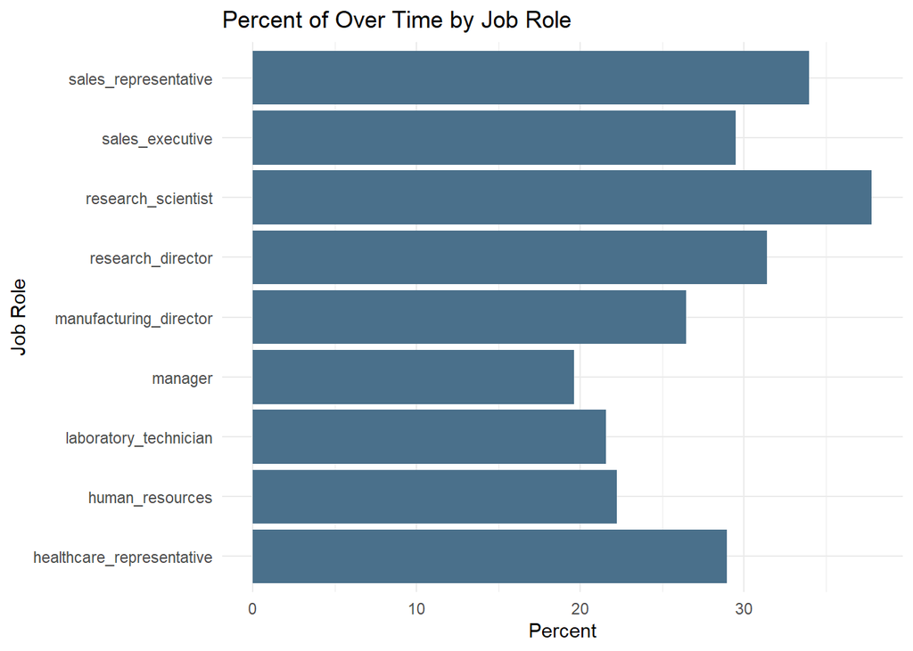

```r
join %>% ggplot(aes(x = job_role, y = perc)) + geom_bar(stat = 'identity', fill = 'skyblue4') + theme_minimal() + coord_flip() + ggtitle("Percent of Over Time by Job Role") + labs(x = "Job Role", y = "Percent")
```

### Analysis:

#### In this case, there is a notable difference between job roles in over time. Manager role had the lowest percentage of over time with 19.6% and research scientist had the highest percentage of over time with 37.8%. In the interest of lowering attrition rates, especially among those roles with higher percentages, it is recommendable to limit over time.

#### I also examined elements of gender parity with respect to job roles. First, we looked at the distribution of monthly income between genders in each job role. Then, I examined job role occupancy by gender.

```r
### Gender parity t-test with respect to monthly income

mon_inc_male <- CStudy2_data %>% select(monthly_income, gender) %>% filter(gender == "Male")
mon_inc_female <- CStudy2_data %>% select(monthly_income, gender) %>% filter(gender == "Female")
t.test(mon_inc_male$monthly_income, mon_inc_female$monthly_income)
```

```
##
##  Welch Two Sample t-test
##
## data:  mon_inc_male$monthly_income and mon_inc_female$monthly_income
## t = -1.6207, df = 747.5, p-value = 0.1055
## alternative hypothesis: true difference in means is not equal to 0
## 95 percent confidence interval:
##  -1140.8560   109.0107
## sample estimates:
## mean of x mean of y
##  6180.337  6696.260
```

#### First, I ran a t-test to establish whether across all job roles there was any difference in monthly income between male and female employees. At a 0.05 significance level, there is not enough evidence to suggest that there is any difference between male and female employees with respect to monthly income (p-value = 0.1055, Welch Two sample t-test).

```r
CStudy2_data %>% select(gender, monthly_income, job_role) %>% group_by(job_role, gender) %>% arrange(job_role) %>% summarise(mean(monthly_income))
```

```
## # A tibble: 18 × 3
## # Groups:   job_role [9]
##    job_role                  gender `mean(monthly_income)`
##    <fct>                     <fct>                   <dbl>
##  1 healthcare_representative Female                  7514.
##  2 healthcare_representative Male                    7375.
##  3 human_resources           Female                  3383.
##  4 human_resources           Male                    3236.
##  5 laboratory_technician     Female                  3384.
##  6 laboratory_technician     Male                    3141.
##  7 manager                   Female                 17156.
##  8 manager                   Male                   17237.
##  9 manufacturing_director    Female                  7452.
## 10 manufacturing_director    Male                    7558.
## 11 research_director         Female                 14874.
## 12 research_director         Male                   16470.
## 13 research_scientist        Female                  3411.
## 14 research_scientist        Male                    3167.
## 15 sales_executive           Female                  6795.
## 16 sales_executive           Male                    6955.
## 17 sales_representative      Female                  2676.
## 18 sales_representative      Male                    2630.
```

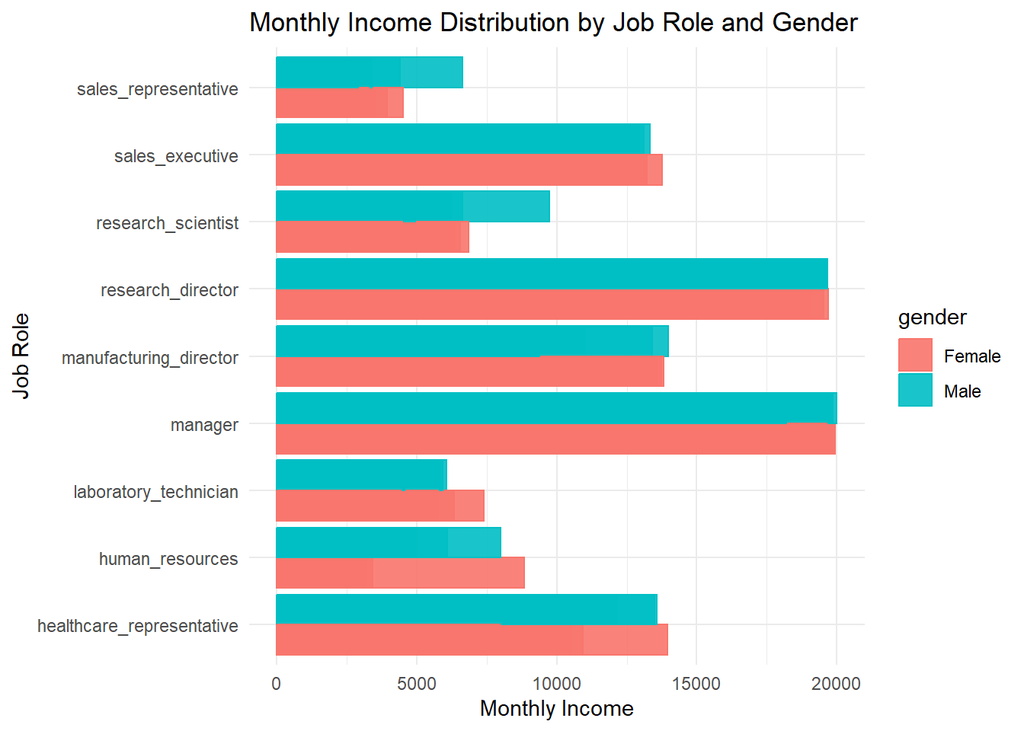

```r
CStudy2_data %>% select(gender, monthly_income, job_role) %>% ggplot(aes(x = job_role, y = monthly_income, color = gender, fill = gender)) + geom_bar(stat = 'identity', alpha = 0.9, position = 'dodge') + coord_flip() + theme_minimal() + ggtitle("Monthly Income Distribution by Job Role and Gender") + labs(x = "Job Role", y = "Monthly Income")
```

#### Lastly, I examined the proportion of employees by gender in each role.

```r
### Gender parity with respect to job_role occupancy

CStudy2_data %>% select(gender, job_role) %>% group_by(job_role) %>% arrange(job_role) %>% count(gender)
```

```
## # A tibble: 18 × 3
## # Groups:   job_role [9]
##    job_role                  gender     n
##    <fct>                     <fct>  <int>
##  1 healthcare_representative Female    33
##  2 healthcare_representative Male      43
##  3 human_resources           Female     9
##  4 human_resources           Male      18
##  5 laboratory_technician     Female    51
##  6 laboratory_technician     Male     102
##  7 manager                   Female    25
##  8 manager                   Male      26
##  9 manufacturing_director    Female    43
## 10 manufacturing_director    Male      44
## 11 research_director         Female    23
## 12 research_director         Male      28
## 13 research_scientist        Female    65
## 14 research_scientist        Male     107
## 15 sales_executive           Female    79
## 16 sales_executive           Male     121
## 17 sales_representative      Female    26
## 18 sales_representative      Male      27
```

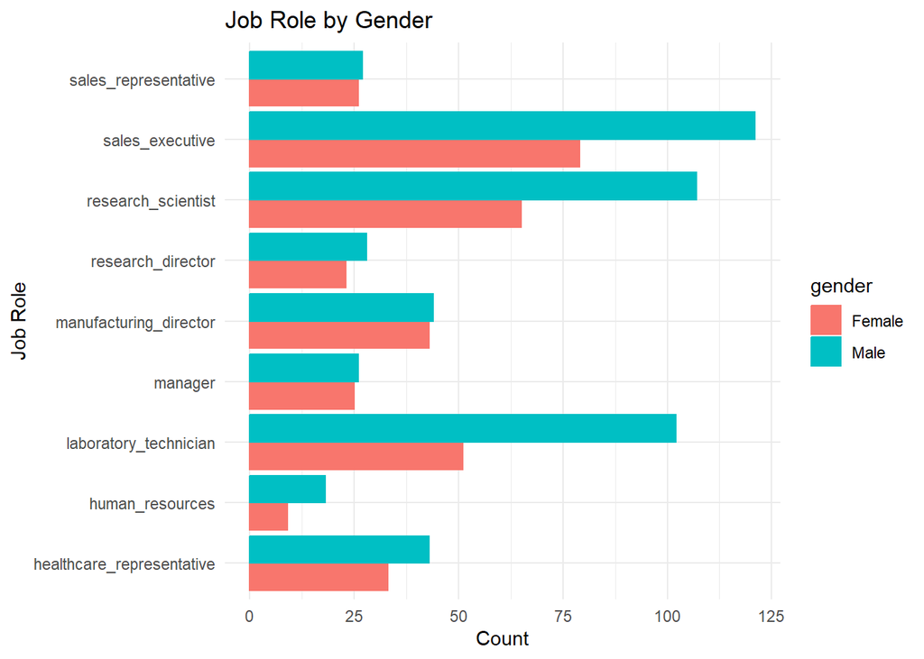

```r
CStudy2_data %>% select(gender, job_role) %>% ggplot(aes(x = job_role, color = gender, fill = gender)) + geom_bar(position = 'dodge') + coord_flip() + theme_minimal() + ggtitle("Job Role by Gender") + labs(x = "Job Role", y = "Count")
```

### Analysis:

#### In this aspect, for every role accounted for, there was a higher share of male employees that occupied the role compared to female employees. Some roles, like Manager and Manufacturing Director, showed only a slight difference, while others like Laboratory Technician, Sales Executive, and Research Scientist, showed an M:F ratio of 2:1, 3:2, and 3:2, respectively.